# Edge Dryspot Detection in Human Hippocampus Data

```r
library(SpatialDryArtifacts)
```

```r
library(ExperimentHub)
library(ggplot2)
library(gridExtra)
```

Introduction This vignette demonstrates how to use SpatialDryArtifacts to detect and classify edge dryspots in spatial transcriptomics data using human hippocampus samples.

Loading Data We’ll use the human hippocampus dataset from ExperimentHub:

```r
# Load hippocampus data
eh <- ExperimentHub()
```

```
#> snapshotDate(): 2025-04-12
```

```r
myfiles <- query(eh, "humanHippocampus2024")
spatial_hpc_spe <- myfiles[["EH9605"]]
```

```
#> see ?humanHippocampus2024 and browseVignettes('humanHippocampus2024') for documentation
#> loading from cache
```

```r
cat("Total samples:", length(unique(spatial_hpc_spe$sample_id)), "\n")
```

```
#> Total samples: 36
```

```r
cat("Total spots:", ncol(spatial_hpc_spe), "\n")
```

```
#> Total spots: 150917
```

Edge Dryspot Detection We’ll demonstrate detection using balanced parameters that provide good sensitivity while avoiding over-detection:

```r
# Apply edge dryspot detection to all samples
spe_detected <- detectEdgeDryspots(
  spatial_hpc_spe,
  qc_metric = "sum_gene",
  samples = "sample_id",
  mad_threshold = 1.8,
  edge_threshold = 0.2,
  min_cluster_size = 3,
  name = "edge_dryspot"
)
```

```
#> Detecting edges with edge_threshold=0.2 and min_cluster_size=3...
#> Number of samples with edges detected: 25
#> Samples with edges detected: V10B01-086_D1, V10B01-086_C1, V11L05-333_B1, V11L05-333_C1, V10B01-085_B1, V10B01-085_C1, V10B01-086_B1, V11L05-335_C1, V11L05-335_B1, V11L05-335_A1, V11U08-084_A1, V11U08-084_D1, V11A20-297_C1, V11A20-297_D1, V11L05-335_D1, V11A20-297_A1, V11U08-081_B1, V11L05-336_A1…
#> Finding problem areas...
#> Edge dryspot detection completed with enhanced sensitivity!
#>   - Edge threshold: 0.2 (vs. previous 0.75)
#>   - Min cluster size: 3 (vs. previous hard-coded 40)
```

```r
# Apply enhanced classification
spe_classified <- classifyEdgeDryspots(spe_detected)
```

```
#> Classifying edge dryspots with enhanced categories...
#> Number of problem areas marked for removal: 0
#> Enhanced edge dryspot classification completed!
#> Classifications added:
#>   - Backward compatible: edge_dryspot_binary, edge_dryspot_classification
#>   - Enhanced: edge_dryspot_enhanced, edge_dryspot_edge_zone, edge_dryspot_sample_type
#>   - Edge zones and sample types will be implemented in subsequent phases
```

Visualization: QC Metrics and Detection Results We’ll create a comprehensive visualization showing QC metrics and detection results for all samples:

```r
# Get all unique samples
all_samples <- unique(spe_classified$sample_id)

# Create plotting function for each sample
create_sample_plots <- function(sample_id, spe_data) {

  # Extract single sample
  spe_sample <- spe_data[, spe_data$sample_id == sample_id]
  coords <- spatialCoords(spe_sample)
  in_tissue <- spe_sample$in_tissue

  plot_data <- data.frame(
    x = coords[in_tissue, 1],
    y = coords[in_tissue, 2],
    sum_umi = spe_sample$sum_umi[in_tissue],
    sum_gene = spe_sample$sum_gene[in_tissue],
    expr_chrM_ratio = ifelse(is.na(spe_sample$expr_chrM_ratio[in_tissue]), 0,
                             spe_sample$expr_chrM_ratio[in_tissue]),
    edge_flagged = spe_sample$edge_dryspot_edge[in_tissue]
  )

  # Base theme
  base_theme <- theme_void() +
    theme(plot.title = element_text(size = 8, hjust = 0.5),
          legend.position = "none")

  # Create 4 plots per sample
  p1 <- ggplot(plot_data, aes(x = x, y = y, color = log10(sum_umi + 1))) +
    geom_point(size = 0.3, alpha = 0.7) +
    scale_color_viridis_c(name = "log10(UMI)") +
    ggtitle(paste(sample_id, "- UMI")) +
    base_theme + coord_fixed()

  p2 <- ggplot(plot_data, aes(x = x, y = y, color = log10(sum_gene + 1))) +
    geom_point(size = 0.3, alpha = 0.7) +
    scale_color_viridis_c(name = "log10(Gene)", option = "plasma") +
    ggtitle(paste(sample_id, "- Genes")) +
    base_theme + coord_fixed()

  p3 <- ggplot(plot_data, aes(x = x, y = y, color = expr_chrM_ratio)) +
    geom_point(size = 0.3, alpha = 0.7) +
    scale_color_viridis_c(name = "Mito Ratio", option = "inferno") +
    ggtitle(paste(sample_id, "- Mito")) +
    base_theme + coord_fixed()

  p4 <- ggplot(plot_data, aes(x = x, y = y, color = edge_flagged)) +
    geom_point(size = 0.3, alpha = 0.7) +
    scale_color_manual(values = c("FALSE" = "lightgray", "TRUE" = "red"),
                       name = "Edge") +
    ggtitle(paste(sample_id, "- Flagged")) +
    base_theme + coord_fixed()

  return(list(p1, p2, p3, p4))
}

# Generate plots for all samples
cat("Generating plots for", length(all_samples), "samples...\n")
```

```
#> Generating plots for 36 samples...
```

[figure not shown]

```r
all_plots <- list()

for (sample_id in all_samples) {
  sample_plots <- create_sample_plots(sample_id, spe_classified)
  all_plots <- append(all_plots, sample_plots)
}

# Create combined visualization (36 rows x 4 columns)
combined_plot <- do.call(gridExtra::grid.arrange, c(
  all_plots,
  ncol = 4,  # 4 columns: UMI, Genes, Mito, Flagged
  nrow = length(all_samples),  # One row per sample
  top = "Human Hippocampus Edge Dryspot Detection - All Samples"
))
```

```r
print(combined_plot)
```

Classification Summary Let’s examine the enhanced classification system:

```r
# Create classification summary table
classification_summary <- table(spe_classified$edge_dryspot_enhanced)
print("Enhanced Classification Summary:")
```

```
#> [1] "Enhanced Classification Summary:"
```

```r
print(classification_summary)
```

```
#>
#>  edge_dryspot          none small_cluster
#>          1532        145405          3980
```

```r
# Calculate percentages
classification_pct <- round(100 * classification_summary / sum(classification_summary), 2)
print("Classification Percentages:")
```

```
#> [1] "Classification Percentages:"
```

```r
print(classification_pct)
```

```
#>
#>  edge_dryspot          none small_cluster
#>          1.02         96.35          2.64
```

```r
# Create summary data frame
summary_df <- data.frame(
  Classification = names(classification_summary),
  Count = as.numeric(classification_summary),
  Percentage = as.numeric(classification_pct)
)

print(summary_df)
```

```
#>   Classification  Count Percentage
#> 1   edge_dryspot   1532       1.02
#> 2           none 145405      96.35
#> 3  small_cluster   3980       2.64
```

```r
# Sample-wise summary
sample_summary <- aggregate(
  spe_classified$edge_dryspot_edge,
  by = list(Sample = spe_classified$sample_id),
  FUN = function(x) sum(x, na.rm = TRUE)
)
names(sample_summary)[2] <- "Edge_Spots_Detected"

sample_summary$Total_Spots <- aggregate(
  spe_classified$in_tissue,
  by = list(spe_classified$sample_id),
  FUN = sum
)$x

sample_summary$Detection_Percentage <- round(
  100 * sample_summary$Edge_Spots_Detected / sample_summary$Total_Spots, 2
)

print("Sample-wise Detection Summary:")
```

```
#> [1] "Sample-wise Detection Summary:"
```

```r
print(sample_summary)
```

```
#>           Sample Edge_Spots_Detected Total_Spots Detection_Percentage
#> 1  V10B01-085_A1                   0        3654                 0.00
#> 2  V10B01-085_B1                  89        3263                 2.73
#> 3  V10B01-085_C1                  55        3738                 1.47
#> 4  V10B01-085_D1                   0        3348                 0.00
#> 5  V10B01-086_A1                   0        4655                 0.00
#> 6  V10B01-086_B1                  72        3964                 1.82
#> 7  V10B01-086_C1                  23        2606                 0.88
#> 8  V10B01-086_D1                   9        3389                 0.27
#> 9  V11A20-297_A1                   2        4432                 0.05
#> 10 V11A20-297_B1                   0        4659                 0.00
#> 11 V11A20-297_C1                   5        3429                 0.15
#> 12 V11A20-297_D1                   8        3412                 0.23
#> 13 V11L05-333_A1                   0        4969                 0.00
#> 14 V11L05-333_B1                 359        4985                 7.20
```

[output cut: 22 more lines]

Quality Control Validation Finally, let’s validate that flagged spots have lower quality metrics:

```r
# Create QC comparison data
in_tissue_data <- spe_classified[, spe_classified$in_tissue]

qc_data <- data.frame(
  sum_umi = in_tissue_data$sum_umi,
  sum_gene = in_tissue_data$sum_gene,
  expr_chrM_ratio = ifelse(is.na(in_tissue_data$expr_chrM_ratio), 0,
                           in_tissue_data$expr_chrM_ratio),
  flagged = in_tissue_data$edge_dryspot_edge
)

# Calculate median differences
flagged_umi <- median(qc_data$sum_umi[qc_data$flagged])
nonflagged_umi <- median(qc_data$sum_umi[!qc_data$flagged])

flagged_gene <- median(qc_data$sum_gene[qc_data$flagged])
nonflagged_gene <- median(qc_data$sum_gene[!qc_data$flagged])

cat("QC Validation Results:\n")
```

```
#> QC Validation Results:
```

```r
cat("Flagged spots - Median UMI:", flagged_umi, "\n")
```

```
#> Flagged spots - Median UMI: 408.5
```

```r
cat("Non-flagged spots - Median UMI:", nonflagged_umi, "\n")
```

```
#> Non-flagged spots - Median UMI: 2088
```

```r
cat("UMI difference:", nonflagged_umi - flagged_umi, "\n\n")
```

```
#> UMI difference: 1679.5
```

```r
cat("Flagged spots - Median Genes:", flagged_gene, "\n")
```

```
#> Flagged spots - Median Genes: 306
```

```r
cat("Non-flagged spots - Median Genes:", nonflagged_gene, "\n")
```

```
#> Non-flagged spots - Median Genes: 1179
```

```r
cat("Gene difference:", nonflagged_gene - flagged_gene, "\n")
```

```
#> Gene difference: 873
```

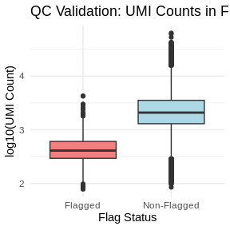

```r
# Create validation boxplot
qc_data$flag_status <- ifelse(qc_data$flagged, "Flagged", "Non-Flagged")

validation_plot <- ggplot(qc_data, aes(x = flag_status, y = log10(sum_umi + 1))) +
  geom_boxplot(fill = c("lightcoral", "lightblue")) +
  labs(title = "QC Validation: UMI Counts in Flagged vs Non-Flagged Spots",
       x = "Flag Status", y = "log10(UMI Count)") +
  theme_minimal()

print(validation_plot)
```

The detection successfully identifies problematic spots while preserving high-quality tissue for downstream analysis.